# Autocorrelation case

## About PCA

The principal components of a collection of points in a real coordinate space are a sequence of p unit vectors, where the i-th vector is the direction of a line that best fits the data while being orthogonal to the first i-1 vectors. Here, a best-fitting line is defined as one that minimizes the average squared distance from the points to the line. These directions constitute an orthonormal basis in which different individual dimensions of the data are linearly uncorrelated. Principal component analysis (PCA) is the process of computing the principal components and using them to perform a change of basis on the data, sometimes using only the first few principal components and ignoring the rest.

## decathlon example

I basically follow http://factominer.free.fr/factomethods/principal-components-analysis.html for the PCA usage. Below shows the decathlon data set.

```r
library(FactoMineR)
data(decathlon)
data <- decathlon
data
```

```
##              100m Long.jump Shot.put High.jump  400m 110m.hurdle Discus
## SEBRLE      11.04      7.58    14.83      2.07 49.81       14.69  43.75
## CLAY        10.76      7.40    14.26      1.86 49.37       14.05  50.72
## KARPOV      11.02      7.30    14.77      2.04 48.37       14.09  48.95
## BERNARD     11.02      7.23    14.25      1.92 48.93       14.99  40.87
## YURKOV      11.34      7.09    15.19      2.10 50.42       15.31  46.26
## WARNERS     11.11      7.60    14.31      1.98 48.68       14.23  41.10
## ZSIVOCZKY   11.13      7.30    13.48      2.01 48.62       14.17  45.67
## McMULLEN    10.83      7.31    13.76      2.13 49.91       14.38  44.41
## MARTINEAU   11.64      6.81    14.57      1.95 50.14       14.93  47.60
## HERNU       11.37      7.56    14.41      1.86 51.10       15.06  44.99
## BARRAS      11.33      6.97    14.09      1.95 49.48       14.48  42.10
## NOOL        11.33      7.27    12.68      1.98 49.20       15.29  37.92
## BOURGUIGNON 11.36      6.80    13.46      1.86 51.16       15.67  40.49
## Sebrle      10.85      7.84    16.36      2.12 48.36       14.05  48.72
## Clay        10.44      7.96    15.23      2.06 49.19       14.13  50.11
## Karpov      10.50      7.81    15.93      2.09 46.81       13.97  51.65
## Macey       10.89      7.47    15.73      2.15 48.97       14.56  48.34
## Warners     10.62      7.74    14.48      1.97 47.97       14.01  43.73
## Zsivoczky   10.91      7.14    15.31      2.12 49.40       14.95  45.62
## Hernu       10.97      7.19    14.65      2.03 48.73       14.25  44.72
## Nool        10.80      7.53    14.26      1.88 48.81       14.80  42.05
## Bernard     10.69      7.48    14.80      2.12 49.13       14.17  44.75
## Schwarzl    10.98      7.49    14.01      1.94 49.76       14.25  42.43
## Pogorelov   10.95      7.31    15.10      2.06 50.79       14.21  44.60
## Schoenbeck  10.90      7.30    14.77      1.88 50.30       14.34  44.41
## Barras      11.14      6.99    14.91      1.94 49.41       14.37  44.83
## Smith       10.85      6.81    15.24      1.91 49.27       14.01  49.02
## Averyanov   10.55      7.34    14.44      1.94 49.72       14.39  39.88
## Ojaniemi    10.68      7.50    14.97      1.94 49.12       15.01  40.35
## Smirnov     10.89      7.07    13.88      1.94 49.11       14.77  42.47
## Qi          11.06      7.34    13.55      1.97 49.65       14.78  45.13
## Drews       10.87      7.38    13.07      1.88 48.51       14.01  40.11
## Parkhomenko 11.14      6.61    15.69      2.03 51.04       14.88  41.90
## Terek       10.92      6.94    15.15      1.94 49.56       15.12  45.62
## Gomez       11.08      7.26    14.57      1.85 48.61       14.41  40.95
## Turi        11.08      6.91    13.62      2.03 51.67       14.26  39.83
## Lorenzo     11.10      7.03    13.22      1.85 49.34       15.38  40.22
## Karlivans   11.33      7.26    13.30      1.97 50.54       14.98  43.34
## Korkizoglou 10.86      7.07    14.81      1.94 51.16       14.96  46.07
```

[output cut: 29 more lines]

```
## Smith             4.20    61.52 272.74   14   8023    OlympicG
## Averyanov         4.80    54.51 271.02   15   8021    OlympicG
## Ojaniemi          4.60    59.26 275.71   16   8006    OlympicG
## Smirnov           4.70    60.88 263.31   17   7993    OlympicG
## Qi                4.50    60.79 272.63   18   7934    OlympicG
## Drews             5.00    51.53 274.21   19   7926    OlympicG
## Parkhomenko       4.80    65.82 277.94   20   7918    OlympicG
## Terek             5.30    50.62 290.36   21   7893    OlympicG
## Gomez             4.40    60.71 269.70   22   7865    OlympicG
## Turi              4.80    59.34 290.01   23   7708    OlympicG
## Lorenzo           4.50    58.36 263.08   24   7592    OlympicG
## Karlivans         4.50    52.92 278.67   25   7583    OlympicG
## Korkizoglou       4.70    53.05 317.00   26   7573    OlympicG
## Uldal             4.50    60.00 281.70   27   7495    OlympicG
## Casarsa           4.40    58.62 296.12   28   7404    OlympicG
```

Let’s apply PCA to this data set. Column-11 (Rank) and column-12 (Points) are treated as quantitative supplementary variables. Column-13 (Competition) are treated as categorical supplementary variable.

The `PCA()` function shows the results.

```r
# Apply PCA and visualize
#  Input:
#    quanti.sup: quantitative supplementary variables
#    quali.sup: categorical supplementary variables
#  Output:
#    var$coord: For Pcounter
#    ind$coord: For Workload
#    quanti.sup$coord: For supplementary variables
data.pca <- PCA(data, scale.unit = TRUE, quanti.sup=c(11, 12), quali.sup=c(13))
```

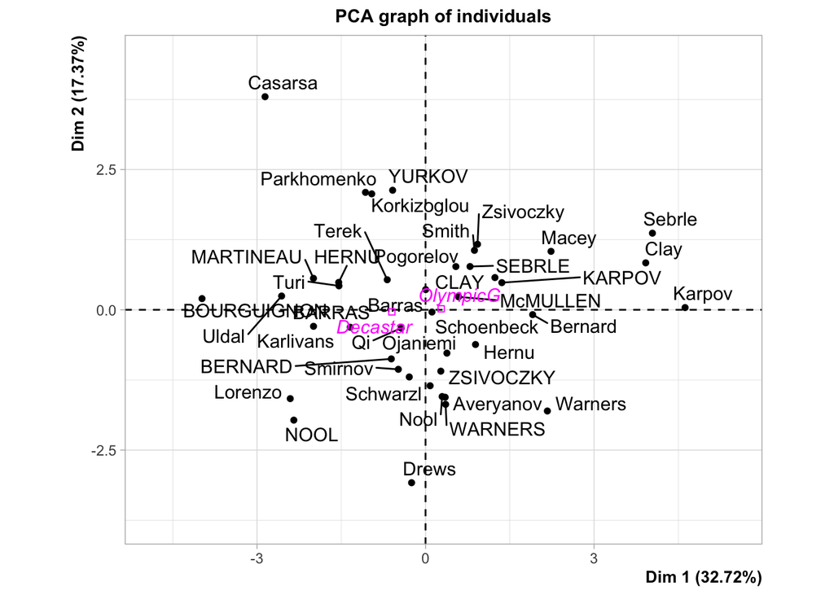

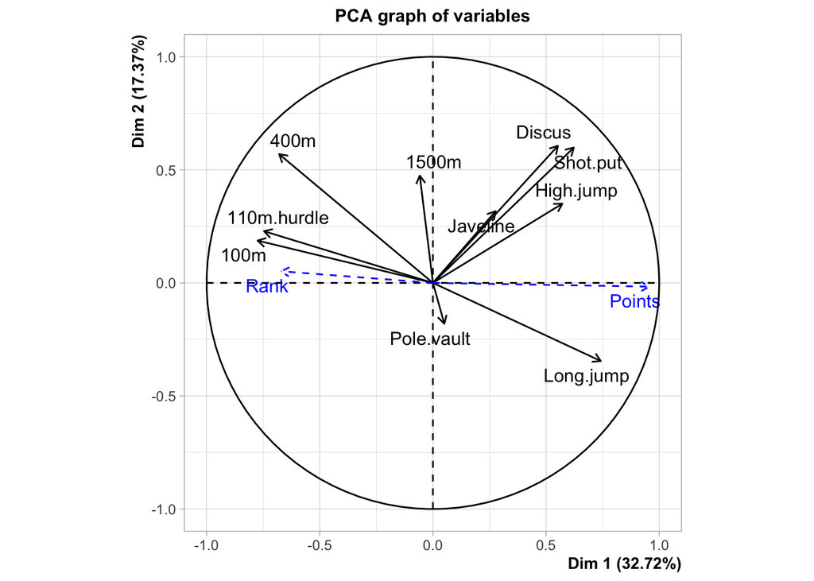

For better plot customization, we can extract the data from the `PCA()` results.

Below is the PCs of the individual.

```r
# Extract workload PCs
data.pca.ind <- data.frame(data.pca$ind$coord)
data.pca.ind
```

```
##                    Dim.1       Dim.2         Dim.3       Dim.4       Dim.5
## SEBRLE       0.791627717  0.77161120  0.8268411940  1.17462736  0.70715903
## CLAY         1.234990563  0.57457807  2.1412469664 -0.35484483 -1.97457138
## KARPOV       1.358214936  0.48402090  1.9562579869 -1.85652411  0.79521472
## BERNARD     -0.609515083 -0.87462853  0.8899406619  2.22061245  0.36163619
## YURKOV      -0.585968338  2.13095422 -1.2251567968  0.87357915  1.25136918
## WARNERS      0.356889530 -1.68495667  0.7665531449 -0.58930466  1.00166155
## ZSIVOCZKY    0.271774781 -1.09377558 -1.2827673831 -1.62156457  0.04407327
## McMULLEN     0.587516189  0.23072991 -0.4176329823 -1.52423275  0.25151965
## MARTINEAU   -1.995359298  0.56099598 -0.7299466011 -0.54219127  1.57821348
## HERNU       -1.546076462  0.48838301  0.8407858519  0.33119470 -0.23498029
## BARRAS      -1.341652727 -0.31091157 -0.0003683375 -0.64525336  0.31628748
## NOOL        -2.344973806 -1.96637500 -1.3364815492  0.19530310  0.83022767
## BOURGUIGNON -3.979041865  0.19986019  1.3264851034  0.52435051  0.29001247
## Sebrle       4.038448501  1.36582606 -0.2899565043  1.94113411  0.37695454
## Clay         3.919365157  0.83696136  0.2311753205  1.49397212 -1.03760852
## Karpov       4.619987275  0.03999523 -0.0415857980 -1.31352566  0.18772953
## Macey        2.233460566  1.04176620 -1.8643620154 -0.74321353  0.97727010
## Warners      2.168396445 -1.80320025  0.8510173287 -0.28459958 -0.15139464
## Zsivoczky    0.925132183  1.16865180 -1.4774802908  0.80759472  0.87297257
## Hernu        0.889037852 -0.61842522 -0.8982953480 -0.13478508  0.63498488
## Nool         0.295305667 -1.54561667  1.3552601286  2.19972249 -0.03538887
## Bernard      1.906334368 -0.08580429 -0.7571859709 -1.45097918  0.34164564
## Schwarzl     0.081078659 -1.35345710  0.8224866222  0.39909143  0.28836991
## Pogorelov    0.539677028  0.77075099  1.3476197769 -0.55215692  0.97229498
## Schoenbeck   0.114430985 -0.03985061  0.7404039810  0.92884762 -0.85442565
## Barras       0.002145203  0.36033768 -1.5696934888  0.61238304 -0.67506540
## Smith        0.870310570  1.05932552 -1.6434290616 -1.12132654 -2.01990789
## Averyanov    0.349155138 -1.55864999  0.2825354037 -0.02726334 -0.36098809
## Ojaniemi     0.380113999 -0.77244734 -0.3709431419  0.68727919 -0.49925676
## Smirnov     -0.484514213 -1.06066118 -1.2283378499  0.56603194 -0.40718384
## Qi          -0.434466691 -0.32614690 -1.0697978123 -0.20497404 -0.53559673
## Drews       -0.248684024 -3.08167683  1.0548427375 -0.64577513 -0.17841420
## Parkhomenko -1.069429104  2.09318218 -0.9999839029  1.53455272  0.28180687
## Terek       -0.681953059  0.53561440  2.2091259997  0.10862305  1.04315650
## Gomez       -0.289889208 -1.19671611 -1.3061025895  0.07785116 -1.26143770
## Turi        -1.541813056  0.42716773  0.5140859441 -0.14284738 -0.03871969
## Lorenzo     -2.408509980 -1.58292969 -1.5023461069  0.30103076 -0.68195932
## Karlivans   -1.994368727 -0.29418240 -0.3427836937 -1.27206999  0.37322060
## Korkizoglou -0.957829813  2.06638554  2.5865525263 -1.19146757 -0.80089104
## Uldal       -2.562259591  0.24546871 -0.4191406445 -0.02118842 -1.25954121
## Casarsa     -2.857088268  3.79784505  0.0305611909 -0.73769370 -0.77044963
```

Below is the eigen vectors.

```r
# Extract Pcounter eigen vectors
data.pca.var <- data.frame(data.pca$var$coord)
data.pca.var
```

```
##                   Dim.1      Dim.2       Dim.3       Dim.4       Dim.5
## 100m        -0.77471983  0.1871420 -0.18440714 -0.03781826  0.30219639
## Long.jump    0.74189974 -0.3454213  0.18221105  0.10178564  0.03667805
## Shot.put     0.62250255  0.5983033 -0.02337844  0.19059161  0.11115082
## High.jump    0.57194530  0.3502936 -0.25951193 -0.13559420  0.55543957
## 400m        -0.67960994  0.5694378  0.13146970  0.02930198 -0.08769157
## 110m.hurdle -0.74624532  0.2287933 -0.09263738  0.29083103  0.16432095
## Discus       0.55246652  0.6063134  0.04295225 -0.25967143 -0.10482712
## Pole.vault   0.05034151 -0.1803569  0.69175665  0.55153397  0.32995932
## Javeline     0.27711085  0.3169891 -0.38965541  0.71227728 -0.30512892
## 1500m       -0.05807706  0.4742238  0.78214280 -0.16108904 -0.15356189
```

Below is the quantitative supplementary vectors.

```r
# Extract quantitative supplementary vectors
data.pca.quanti.sup <- data.frame(data.pca$quanti.sup$coord)
data.pca.quanti.sup
```

```
##             Dim.1       Dim.2       Dim.3      Dim.4      Dim.5
## Rank   -0.6705104  0.05139812 -0.05834304 -0.1614077 -0.3500257
## Points  0.9561543 -0.01651613 -0.06635212  0.2360079  0.1136256
```

Below is the categorical supplementary vectors.

```r
# Extract categorical supplementary vectors
data.pca.quali.sup <- data.frame(data.pca$quali.sup$coord)
data.pca.quali.sup
```

```
##               Dim.1       Dim.2      Dim.3       Dim.4      Dim.5
## Decastar -0.6001211 -0.03765491  0.2889044 -0.13955756  0.4013710
## OlympicG  0.2786276  0.01748264 -0.1341342  0.06479458 -0.1863508
```

Once we retrive all the data, we can plot them using ggplot.

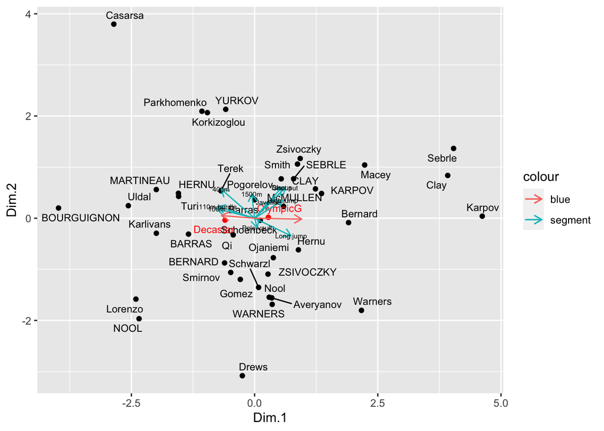

```r
# Plot
library(ggplot2)
library(ggrepel)
ggplot(data.pca.ind, aes(x=Dim.1, y=Dim.2)) +
  geom_point() + geom_text_repel(aes(label=rownames(data.pca.ind)), size=3) +
  geom_point(data=data.pca.quali.sup, aes(x=Dim.1, y=Dim.2), color="red") + geom_text_repel(data=data.pca.quali.sup, aes(label=rownames(data.pca.quali.sup)), color="red", size=3) +
  geom_segment(data=data.pca.var, aes(x = 0, y = 0, xend = Dim.1, yend = Dim.2, colour = "segment"), arrow = arrow(length = unit(0.1, "inches"))) +
  geom_text(data=data.pca.var, aes(label=rownames(data.pca.var)), size=2) +
  geom_segment(data=data.pca.quanti.sup, aes(x = 0, y = 0, xend = Dim.1, yend = Dim.2, colour = "blue"), arrow = arrow(length = unit(0.1, "inches")))
```

Below plots the variance explained by PCs.

```r
library("factoextra")
```

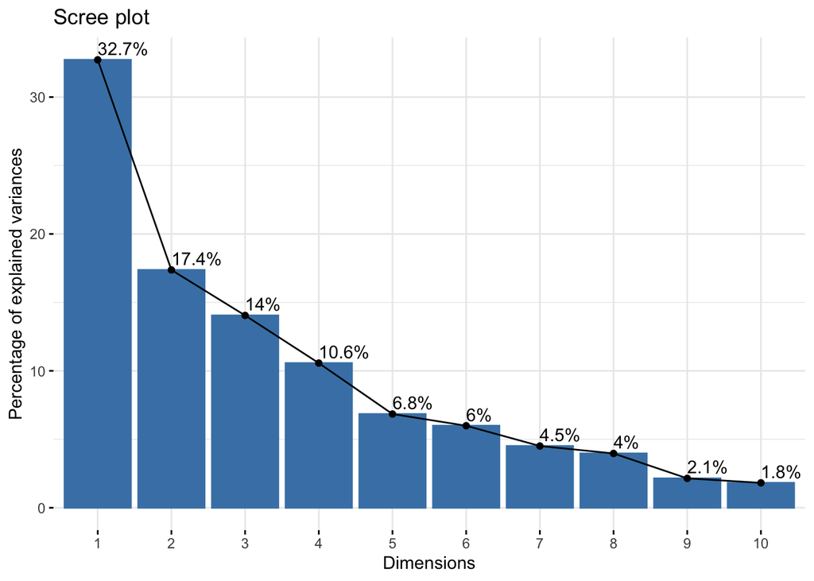

```r
# Plot the PCA variance
fviz_eig(data.pca, addlabels=TRUE)
```

We can also use `cor()` and `corrplot()` to visualize the correlation of 2 variables.

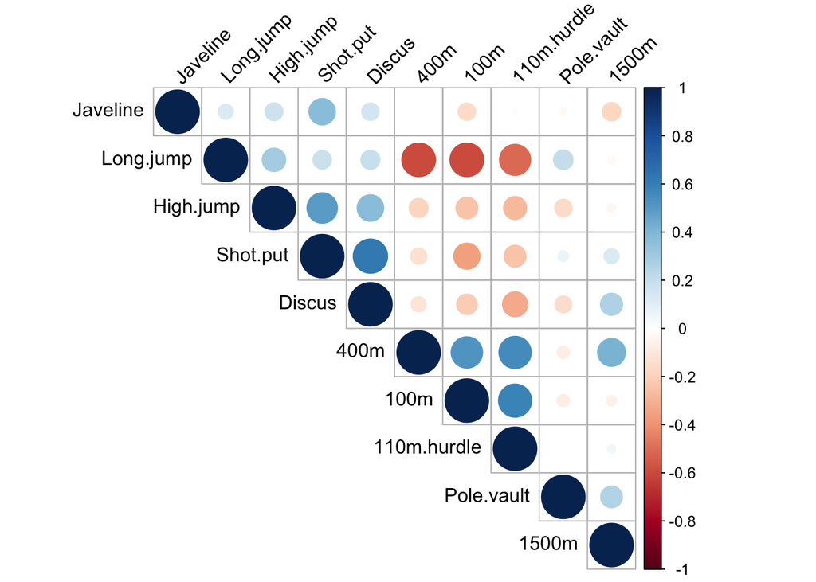

```r
# Ref: http://www.sthda.com/english/wiki/wiki.php?id_contents=7851
library("corrplot")
cor.mat <- round(cor(data[1:10]),2)
corrplot(cor.mat, type="upper", order="hclust",
         tl.col="black", tl.srt=45)
```